# Prepare ANES 1952–2020 voting blocs

Cole Tanigawa-Lau

Updated: Sep 20, 2023 at 21:59:05 PDT.

Working directory: `/home/groups/jgrimmer/trump_blocs`.

Reads:

- data/anes_timeseries_cdf/anes_timeseries_cdf_rawdata.txt
- data/anes_waves/*

Writes:

- data/anes_clean.rds

# Setup

```r
rm(list = ls())

library(haven)
library(dplyr)
library(data.table)

source("code/functions.R")
```

## Load data

```r
anes <- fread("data/anes_timeseries_cdf_csv_20211118/anes_timeseries_cdf_csv_20211118.csv")
```

# Renaming

Select variables to work with.

```r
varlabs <-
    tribble(~ variable, ~ label,
            "VCF0017", "mode",
            "VCF0004",  "year",
            # "VCF0006",  "uid"
            "VCF0012",  "form",
            "VCF0006a",  "resp_id",
            "VCF0006",   "respid2",
            # Combined-sample weights
            "VCF0009z",  "weight",
            "VCF0901b", "state",
            "VCF0901a", "fips",

            "VCF0105b",  "race",
            "VCF0107",   "hisp_origin",
            "VCF0101",    "age",
            # "VCF0102",    "age_bin",
            # "VCF0103",    "birth_cohort",
            "VCF0104",    "gender",
            "VCF0140",    "educ",
            "VCF0111",    "urban",
            "VCF0112",    "region",
            "VCF0113",    "south",
            "VCF0114",    "faminc",
            "VCF0301",    "pid7",
            "VCF0303",    "pid3",
            "VCF0305",    "party_strength",
            "VCF0803",    "ideo7",
            # "VCF0310",    "election_interest",
            "VCF0704",    "vote_pres",
            # "VCF0707",    "vote_house",
            # "VCF0708",    "vote_senate",
            # "VCF9025",    "vote_gov",
            "VCF0703",    "turnout",

            ##### Picked from the google sheet based on availability
            "VCF0206", "therm_black",

            "VCF9039", "resent_slavery",
            "VCF9040", "resent_favors",
            "VCF9041", "resent_try",
            "VCF9042", "resent_deserve",

            ##### For comparison with MWK
            "VCF0253", "therm_feminist",
            "VCF0217", "therm_hispanic",
            "VCF0232", "therm_gay",

            "VCF9269", "therm_christian", ## WATCH OUT! for some reason these are coded
            "VCF9267", "therm_muslim",    ## like 2020, with negative values,
                                          ## not values >97, indicating NA.
            "VCF0207", "therm_white",

            "VCF0218", "therm_party_dem",
            "VCF0224", "therm_party_rep",

            # "VCF0813", "blacks_position_changed",
            # "VCF0814", "civil_rights_fast",
            # "VCF0815", "segregation",
            # "VCF0816", "school_integr",
            # "VCF0817", "busing",
            # "VCF0818", "fair_jobshousing",
            # "VCF0819", "open_housing",
            # "VCF0820", "whites_segr",
            # "VCF0821", "blacks_desgr",

            "VCF0830", "blacks_lessaid",
            # "VCF0860", "nbrhd_race_comp",
            # "VCF0867", "affact1",
            # "VCF0867a", "affact2",
            # "VCF0879",  "incr_immigr",

    )
```

```r
anes <- dplyr::select(anes, varlabs$variable)
```

Rename variables.

```r
setnames(anes, varlabs$variable, varlabs$label)
```

# Recoding

```r
anes_recode <-
    mutate(anes,
           source = "ANES",
           mode = recode(mode, `0` = "FTF", `1` = "phone pre", `2` = "phone post",
                         `3` = "phone", `4` = "online"),
           year = year,
           age  = ifelse(age < 17, NA, age),
           region = recode(region,
                           `1` = "Northeast", `2` = "Midwest",
                           `3` = "South", `4` = "West"),
           south = as.numeric(state %in%
                                  # Confederacy
                                  c("TN", "VA", "NC", "SC", "FL",
                                    "GA", "AL", "MS", "LA", "AR", "TX",
                                    # Schickler adds these
                                    "OK", "KY")),
           urban = recode(urban, `1` = "urban", `2` = "suburban", `3` = "rural",
                          `0` = NA_character_),
           gender = recode_factor(gender, `1` = "male", `2` = "female",
                                  `3` = "other", .default = NA_character_),
           ideo7  = ifelse(ideo7 %in% c(0, 9), NA, ideo7),
           educ = recode_factor(educ,
                                `1` = "HS or less", `2` = "HS or less",
                                `3` = "some college", `4` = "college",
                                .default = NA_character_),
           race = recode_factor(race,
                                `1` = "white", `2` = "black", `3` = "hispanic", `4` = "other",
                                `9` = NA_character_, `0` = NA_character_),
           # income, ANES-specific bins
           # 1. 0 to 16 percentile
           # 2. 17 to 33 percentile
           # 3. 34 to 67 percentile
           # 4. 68 to 95 percentile
           # 5. 96 to 100 percentile
           # 0. DK; NA; refused to answer; no Pre IW INAP. question not used
           fincome_anes = recode(faminc,
                                 `1` = "0-16ptile",
                                 `2` = "17-33ptile",
                                 `3` = "34-67ptile",
                                 `4` = "68-95ptile",
                                 `5` = "96-100ptile",
                                 .default = NA_character_),

           hisp_origin = recode(hisp_origin,
                                `1` = "mexican", `2` = "puerto rican",
                                `3` = "other", `4` = "other", .default = NA_character_),

           # RECODED FROM PID7 TO MATCH CCES, SEE BELOW
           # pid3 = recode(pid3,
           #               `1` = "dem", `2` = "indep", `3` = "rep",
           #               .default = "other/not sure"),
           pid7 = recode(pid7,
                         `1` = "strong dem", `2` = "weak dem", `3` = "indep dem",
                         `4` = "indep",
                         `5` = "indep rep", `6` = "weak rep", `7` = "strong rep",
                         .default = "other/not sure"),
           party_strength = recode(party_strength,
                                   `1` = "independent", `2` = "lean independent",
                                   `3` = "weak partisan", `4` = "strong partisan",
                                   `0` = NA_character_),
           turnout = recode(turnout,
                            `1` = "unregistered", `2` = "did not vote",
                            `3` = "voted", `0` = NA_character_),
           vote_pres = recode(vote_pres,
                              `1` = "dem", `2` = "rep", `3` = "third",
                              `0` = NA_character_),

           therm_feminist  = ifelse(therm_feminist < 0, NA, therm_feminist),
           therm_muslim    = ifelse(therm_muslim < 0, NA, therm_muslim),
           therm_christian = ifelse(therm_christian < 0, NA, therm_christian),

           # weird, but it's according to the codebook. 97+ was coded as 97.
           therm_black     = ifelse(therm_black      %in% 98:99, NA, therm_black),
           therm_hispanic  = ifelse(therm_hispanic   %in% 98:99, NA, therm_hispanic),
           therm_gay       = ifelse(therm_gay        %in% 98:99, NA, therm_gay),
           therm_white     = ifelse(therm_white      %in% 98:99, NA, therm_white),
           therm_party_dem = ifelse(therm_party_dem  %in% 98:99, NA, therm_party_dem),
           therm_party_rep = ifelse(therm_party_rep  %in% 98:99, NA, therm_party_rep),

           blacks_lessaid = ifelse(blacks_lessaid %in% c(9, 0), NA, blacks_lessaid),

           # Create indicator variables
           white = as.numeric(race == "white"),
           black = as.numeric(race == "black"),
           hispanic = as.numeric(race == "hispanic"),
           # Unregistered voters coded as did not vote (0)
           voted = as.numeric(turnout == "voted"),
           vote_pres_dem = as.numeric(vote_pres == "dem"),
           vote_pres_rep = as.numeric(vote_pres == "rep"),
           vote_pres3    = case_when(vote_pres == "dem" ~ -1L,
                                     vote_pres == "rep" ~  1L,
                     vote_pres == "third" ~ 0L,
                                     turnout   != "voted" ~  NA_integer_)
    )
```

# Code racial resentment

```r
anes_recode <-
  mutate(anes_recode,
         resent_slavery = ifelse(resent_slavery %in% 8:9 | resent_slavery < 0,
                                 NA, resent_slavery),
         resent_favors = ifelse(resent_favors %in% 8:9 | resent_favors < 0,
                                NA, resent_favors),
         resent_try     = ifelse(resent_try     %in% 8:9 | resent_try < 0,
                                 NA, resent_try),
         resent_deserve = ifelse(resent_deserve %in% 8:9 | resent_deserve < 0,
                                 NA, resent_deserve))
```

REVERSE the try-harder and favors questions. Strongly Agree (1) to “Blacks Must Try Harder to Succeed” becomes a (5)—high resentment.

```r
anes_recode <-
  mutate(anes_recode,
         resent_try = 1 + max(resent_try, na.rm = TRUE) - resent_try,
         resent_favors = 1 + max(resent_favors, na.rm = TRUE) - resent_favors)
```

```r
rr_cols <-
 c("resent_slavery", "resent_favors",
   "resent_try", "resent_deserve")

# z-scores averaged across questions
anes_recode[!is.na(resent_slavery),
            racialres_zsc := gen_std_scale(.SD),
             .SDcols = rr_cols
             ]
```

```
## Average interitem correlation after standardizing columns is 0.642
```

## Check racial resentment coding

Higher values of resent_slavery => greater disagreement => higher resentment.

```r
stopifnot(
  anes_recode[ , cor(racialres_zsc, resent_slavery, use = "pa")] > 0
  )
```

Resentment negatively correlated with warm feelings toward Blacks.

```r
stopifnot(
  anes_recode[ , cor(racialres_zsc, therm_black, use = "pa")]  < 0L
)
```

# Add white identity from 2016, 2020 files

1. How important is being white to your identity?
2. How important is it that whites work together to change laws that are unfair to whites
3. How likely is it that many whites are unable to find a job because employers are hiring minorities instead?
4. How much discrimination is there in the United States today against whites?

```r
white_codes <-
  tribble(
    ~ var_anes16, ~ var_anes20, ~ name,
    "V162327"   ,   "V202499x", "white_import",
    "V162316"   ,   "V202483" , "white_work",
    "V162317"   ,   "V202487" , "white_job",
    "V162360"   ,   "V202530" , "white_discrim",
    "V160001"   ,   "V200001",  "respid2"
  )

anes16 <- read_dta("data/anes_waves/anes2016/anes_timeseries_2016_Stata13.dta",
                   col_select = white_codes$var_anes16)
anes16$year <- 2016

setnames(anes16, white_codes$var_anes16, white_codes$name)

anes20 <- read_dta("data/anes_waves/anes2020/anes_timeseries_2020_stata_20210719.dta",
                   col_select = white_codes$var_anes20)
anes20$year <- 2020

setnames(anes20, white_codes$var_anes20, white_codes$name)
```

```r
anes1620 <-
  rbind(anes20 %>% mutate(across(everything(), zap_labels)),
        anes16 %>% mutate(across(everything(), zap_labels))) %>%
  mutate(
         # white ID questions all coded so that 1 implies higher on ID scale
         # 1. white ID extremely important
         white_import   = ifelse( ! white_import %in% 1:5, NA, white_import) %>%
                              { (5:1)[.] },

         # 1. working together extremely important
         white_work     = ifelse( ! white_work %in% 1:5, NA, white_work) %>%
                              { (5:1)[.] },

         # 1. no job extremely likely
         white_job      = ifelse( ! white_job %in% 1:5, NA, white_job) %>%
                              { (5:1)[.] },

         # 1. a great deal
         white_discrim  = ifelse( ! white_discrim %in% 1:5, NA, white_discrim) %>%
                              { (5:1)[.] })
```

Merge in the coded white ID variables

```r
white_id_cols <- white_codes$name %>% setdiff("respid2")

setDT(anes1620)
anes_recode[anes1620,
            (white_id_cols) := mget(paste0("i.", white_id_cols)),
            on = c("year", "respid2")
            ]
```

# Add recalled vote choice

Columns for past vote choice are not in the ANES cumulative file.

```r
last_vote_cols <-
  tribble(
    ~ var_anes12,        ~ var_anes16, ~ var_anes20,  ~ name,
    "caseid",               "V160001",    "V200001",  "respid2",
    "interest_voted2008",   "V161005",    "V201102",  "last_voted",
    "interest_whovote2008", "V161006",    "V201103",  "last_vote_pres"
  )
```

```r
anes12 <- read_dta("data/anes_waves/anes2012/anes_timeseries_2012.dta",
                   col_select = last_vote_cols$var_anes12)
anes12$year <- 2012
setnames(anes12, last_vote_cols$var_anes12, last_vote_cols$name)
```

```r
anes16 <- read_dta("data/anes_waves/anes2016/anes_timeseries_2016_Stata13.dta",
                   col_select = last_vote_cols$var_anes16)
anes16$year <- 2016
setnames(anes16, last_vote_cols$var_anes16, last_vote_cols$name)
```

The 2020 ANES split the sample and asked different recalled turnout questions. The “revised” question, V201101, reminded people that their past turnout could be verified.

```r
anes20 <- read_dta("data/anes_waves/anes2020/anes_timeseries_2020_stata_20210719.dta",
                   col_select = c(last_vote_cols$var_anes20, "V201101"))
anes20$year <- 2020
setnames(anes20, last_vote_cols$var_anes20, last_vote_cols$name)

setnames(anes20, "V201101", "last_voted_rev")
```

```r
anes_vote <-
  list(anes12, anes16, anes20) %>%
  lapply(zap_labels) %>%
  bind_rows() %>%
  mutate(last_voted = as.numeric(last_voted == 1),
         last_vote_pres = recode(last_vote_pres,
                                 `1` = "dem", `2` = "rep", `5` = "third",
                                 .default = NA_character_)
         )
```

```r
setDT(anes_vote)

lvcn <- c("last_voted", "last_vote_pres")
anes_recode[anes_vote,
            (lvcn) := mget(paste0("i.", lvcn)),
            on = c("year", "respid2")]
```

# Construct white identity scale

```r
# z-scores averaged across questions within year
anes_recode[!is.na(white_import),
             white_idscale := gen_std_scale(.SD),
             .SDcols = white_codes$name
             ]
```

```
## Average interitem correlation after standardizing columns is 0.362
```

## Checks

```r
stopifnot(
  anes_recode[grep("rep", pid7), mean(white_idscale, na.rm = TRUE)] >
    anes_recode[grep("dem", pid7), mean(white_idscale, na.rm = TRUE)]
)

stopifnot(
  anes_recode[year == 2020,
              weighted.mean(white_idscale, w = weight, na.rm = TRUE)] <
    anes_recode[year == 2016,
                weighted.mean(white_idscale, w = weight, na.rm = TRUE)]
)

anes_recode[year %in% 2016:2020][ ,
            .(mean_white_id = weighted.mean(white_idscale,
                                            w = weight, na.rm = TRUE),
             .N),
            by = .(race, year)]
```

| race | year | mean_white_id | N |
| --- | --- | --- | --- |
| white | 2016 | 0.5857380 | 3038 |
| black | 2016 | NaN | 397 |
| other | 2016 | 0.4651435 | 352 |
| hispanic | 2016 | 0.5019522 | 450 |
| NA | 2016 | NaN | 33 |
| hispanic | 2020 | NaN | 762 |
| other | 2020 | -0.6955975 | 727 |
| white | 2020 | -0.2592443 | 5963 |
| black | 2020 | NaN | 726 |
| NA | 2020 | NaN | 102 |

```r
anes_recode[ , ..white_id_cols] %>% cor(use = "pa")
```

```
##               white_import white_work white_job white_discrim
## white_import     1.0000000  0.2711410 0.2587971     0.1146866
## white_work       0.2711410  1.0000000 0.3806823     0.2234836
## white_job        0.2587971  0.3806823 1.0000000     0.3959274
## white_discrim    0.1146866  0.2234836 0.3959274     1.0000000
```

## Cross tabs

```r
anes_recode[year %in% 2016:2020,
            table(year, white_import, useNA = "always") %>%
              prop.table() %>% round(3)
            ]
```

```
##       white_import
## year       1     2     3     4     5  <NA>
##   2016 0.067 0.039 0.061 0.039 0.024 0.110
##   2020 0.160 0.089 0.103 0.055 0.032 0.221
##   <NA> 0.000 0.000 0.000 0.000 0.000 0.000
```

```r
anes_recode[year %in% 2016:2020,
            table(year, white_work, useNA = "always") %>%
              prop.table() %>% round(3)
            ]
```

```
##       white_work
## year       1     2     3     4     5  <NA>
##   2016 0.044 0.025 0.058 0.045 0.031 0.136
##   2020 0.115 0.066 0.111 0.075 0.055 0.237
##   <NA> 0.000 0.000 0.000 0.000 0.000 0.000
```

```r
anes_recode[year %in% 2016:2020,
            table(year, white_job, useNA = "always") %>%
              prop.table() %>% round(3)
            ]
```

```
##       white_job
## year       1     2     3     4     5  <NA>
##   2016 0.041 0.067 0.055 0.027 0.015 0.135
##   2020 0.211 0.190 0.117 0.046 0.018 0.079
##   <NA> 0.000 0.000 0.000 0.000 0.000 0.000
```

```r
anes_recode[year %in% 2016:2020,
            table(year, white_discrim, useNA = "always") %>%
              prop.table() %>% round(3)
            ]
```

```
##       white_discrim
## year       1     2     3     4     5  <NA>
##   2016 0.091 0.119 0.048 0.014 0.007 0.061
##   2020 0.190 0.241 0.100 0.030 0.017 0.081
##   <NA> 0.000 0.000 0.000 0.000 0.000 0.000
```

## Race breakdown

Missingness by race and year.

```r
anes_recode[year %in% 2016:2020,
            lapply(.SD, function(x) mean(is.na(x))),
            .SDcols = white_id_cols,
            by = .(year, race)
            ]
```

| year | race | white_import | white_work | white_job | white_discrim |
| --- | --- | --- | --- | --- | --- |
| 2016 | white | 0.1487821 | 0.1563529 | 0.1530612 | 0.1599737 |
| 2016 | black | 1.0000000 | 1.0000000 | 1.0000000 | 0.1939547 |
| 2016 | other | 0.6931818 | 1.0000000 | 1.0000000 | 0.2528409 |
| 2016 | hispanic | 0.5622222 | 1.0000000 | 1.0000000 | 0.2355556 |
| 2016 | NA | 1.0000000 | 1.0000000 | 1.0000000 | 0.3939394 |
| 2020 | hispanic | 1.0000000 | 1.0000000 | 0.1496063 | 0.1561680 |
| 2020 | other | 0.7235213 | 0.9642366 | 0.1334250 | 0.1306740 |
| 2020 | white | 0.1093409 | 0.1142043 | 0.1086701 | 0.1106825 |
| 2020 | black | 1.0000000 | 1.0000000 | 0.1308540 | 0.1487603 |
| 2020 | NA | 1.0000000 | 1.0000000 | 0.3333333 | 0.3235294 |

Mean by race and year

```r
anes_recode[year %in% 2016:2020,
            lapply(.SD, function(x) weighted.mean(x, w = weight, na.rm = T)),
            .SDcols = white_id_cols,
            by = .(year, race)
            ]
```

| year | race | white_import | white_work | white_job | white_discrim |
| --- | --- | --- | --- | --- | --- |
| 2016 | white | 2.644989 | 2.966077 | 2.575618 | 2.098277 |
| 2016 | black | NaN | NaN | NaN | 1.830459 |
| 2016 | other | 2.196902 | NaN | NaN | 1.883927 |
| 2016 | hispanic | 2.510199 | NaN | NaN | 1.834224 |
| 2016 | NA | NaN | NaN | NaN | 1.843558 |
| 2020 | hispanic | NaN | NaN | 1.873962 | 1.902749 |
| 2020 | other | 1.731947 | 3.100999 | 1.802142 | 1.961625 |
| 2020 | white | 2.335693 | 2.748013 | 2.227729 | 2.154508 |
| 2020 | black | NaN | NaN | 1.761511 | 1.933850 |
| 2020 | NA | NaN | NaN | 2.089217 | 2.060888 |

## Density plots

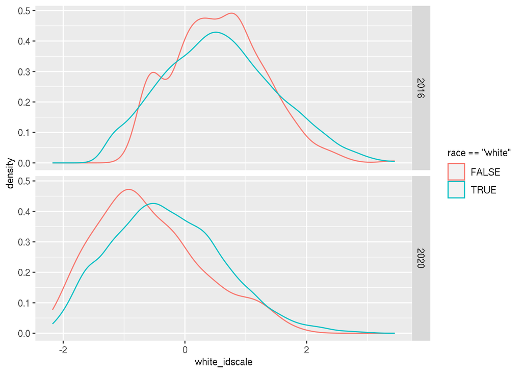

```r
library(ggplot2)

ggplot(anes_recode %>% filter(year %in% 2016:2020)) +
  geom_density(aes(x = white_idscale, color = race == "white")) +
  facet_grid(year ~ .)
```

# Age bins

Copied from Will’s CCES code: age groups in 10-year bands, except under 20 is counted w/ 20s

```r
mfloor <- function(x,base){
    base * floor(x/base)
}

anes_recode[ , age_bin := mfloor(age, 10)]
anes_recode[ , age_bin5 := mfloor(age, 5)]
anes_recode[age < 20, c("age_bin", "age_bin5") := 20]
```

# Missing turnout?

Some years have respondents who reported vote choice but no turnout. That could be a few D.C. residents. In 1972, ANES used a Form II with no turnout question. Both Form I and II are nationally representative, each with 50% of the total 1972 sample. I drop Form II respondents entirely.

```r
setDT(anes_recode)

anes_recode[ ,
             .(num_err = sum(!is.na(vote_pres) & is.na(voted)),
               prop_err = mean(!is.na(vote_pres) & is.na(voted))),
             by = .(year, form)
             ][num_err > 0]
```

| year | form | num_err | prop_err |
| --- | --- | --- | --- |
| 1948 | NA | 390 | 0.589123867 |
| 1972 | 1 | 11 | 0.008017493 |
| 1972 | 2 | 760 | 0.570142536 |
| 2020 | NA | 47 | 0.005676329 |

```r
anes_recode[year == 1972, table(form, turnout)]
```

```
##     turnout
## form did not vote unregistered voted
##    1          112          186   853
##    2            0            0     0
```

```r
anes_recode <- anes_recode[year != 1972 | form == 1]

anes_recode[ ,
             .(num_err = sum(!is.na(vote_pres) & is.na(voted)),
               prop_err = mean(!is.na(vote_pres) & is.na(voted))),
             by = .(year)
             ][num_err > 0]
```

| year | num_err | prop_err |
| --- | --- | --- |
| 1948 | 390 | 0.589123867 |
| 1972 | 11 | 0.008017493 |
| 2020 | 47 | 0.005676329 |

# Will’s recoding of ANES income

```r
# for compatability with Will's code
anes <- anes_recode
source("code/preprocessing/anes_income.R")

anes <-
  group_by(anes, year) %>%
  mutate(faminc_quin =
           ntile(inc_midpoint, 5) %>%
           recode_factor(`1` = "1st",
                         `2` = "2nd",
                         `3` = "3rd",
                         `4` = "4th",
                         `5` = "5th"
                         ),
         faminc_terc =
           ntile(inc_midpoint, 3) %>%
           recode_factor(`1` = "1st", `2` = "2nd", `3` = "3rd")
         )
```

# Make pid3 from pid7

Very strange discrepancy between ANES and CCES versions of the 3-level party ID variable. Creating our own out of the 7-leveled version, which is more consistent across surveys.

```r
anes <-
  mutate(anes,
         pid3 = recode_factor(pid7,
                              `strong dem`     = "dem",
                              `weak dem`       = "dem",
                              `indep dem`      = "dem",
                              `independent`    = "indep",
                              `other/not sure` = "other/not sure",
                              `indep rep`      = "rep",
                              `weak rep`       = "rep",
                              `strong rep`     = "rep",
                              )
         )
```

# Create party-group animosity

These variables copy MWK’s method of aggregating respondents’ FT ratings of party-aligned groups.

```r
anes <-
  mutate(anes,
         demgroup_animosity =
           cbind(therm_black, therm_hispanic,
                   therm_gay, therm_muslim) %>%
             rowMeans() %>%
           # Flip so that warm feelings => lower animosity
           `*`(-1) %>%
           # Rescale range to lie between 0 and 1
           scales::rescale(to = c(0, 1), na.rm = TRUE),

         repgroup_animosity =
           cbind(therm_white, therm_christian) %>%
           rowMeans() %>%
           # Flip so that warm feelings => lower animosity
           `*`(-1) %>%
           # Rescale range to lie between 0 and 1
           scales::rescale(to = c(0, 1), na.rm = TRUE),
         )
```

Select columns for voting bloc analysis.

```r
anes_vb <-
    dplyr::select(anes,
                  mode, year, resp_id, weight,
                  region, south, urban,
                  race, hisp_origin, gender,
                  fincome_anes, faminc_quin, faminc_terc,
                  age, age_bin, educ,
                  pid3, pid7, party_strength, ideo7,
                  racialres = racialres_zsc,

                  # Nearly raw, just recoded missing values as NA
                  resent_slavery,
                  resent_favors,
                  resent_try,
                  resent_deserve,

                  white_idscale,
                  white_import,
                  white_work,
                  white_job,
                  white_discrim,

                  therm_muslim,
                  therm_christian,
                  therm_black,
                  therm_hispanic,
                  therm_gay,
                  therm_white,
                  therm_feminist,
                  therm_party_dem,
                  therm_party_rep,

                  demgroup_animosity,
                  repgroup_animosity,

                  voted, vote_pres_rep, vote_pres_dem,
                  vote_pres3,

                  last_voted, last_vote_pres,

                  source)
```

# Checks

```r
setDT(anes_vb)
therm_cols <- grep("therm", names(anes_vb), value = TRUE)

for(col in therm_cols) assert_that(all(between(na.omit(anes_vb[[col]]), 0, 100)))
```

```r
assert_that(all(between(na.omit(anes_vb[["ideo7"]]), 1, 7)))
```

```
## [1] TRUE
```

# Export

```r
anes_vb[ , year := as.character(year)]
saveRDS(anes_vb, "data/anes_clean.rds")
```